# NHS Borders / Cancer Incidence

# Wrangling and Cleaning

## Load Libraries

```r
library(tidyverse)
library(janitor)
```

## Read In Data

```r
cancer_incidence <- read_csv("data/cancer_incidence_by_health_board.csv") %>%
  clean_names()

five_year_summary <- read_csv("data/five_year_cancer_incidence_summary.csv") %>%
  clean_names()

geography_codes <- read_csv("data/geography_codes_and_labels.csv") %>%
  clean_names()
```

## Filter for NHS Borders Data

```r
cancer_incidence_borders <- cancer_incidence %>%
  filter(hb == "S08000016")

five_year_summary_borders <- five_year_summary %>%
  filter(hb == "S08000016")
```

## Remove Unnecessary Objects

```r
rm(cancer_incidence)
rm(five_year_summary)
rm(geography_codes)
```

The simplest death rate is the so-called crude death rate, which is calculated by dividing the total number of deaths by the total population. However, because the probability of death tends to increase with age, changes in the age-distribution of the population could have an effect on any apparent trend shown by the crude death rate. Age-standardised death rates that are comparable over time and between different countries can be calculated using the European Standard Population (ESP). This is a theoretical population, defined as having a particular distribution by age, which does not change. (https://www.nrscotland.gov.uk/files//statistics/age-standardised-death-rates-esp/2017/age-standardised-17-methodology.pdf)

For our analysis, we will consider number of incidences & EASR.

EASR: Allows for comparing of trends over time, discounting age variations. Incidences: Raw count of incidences.

## Select Only Necessary Rows

```r
cancer_incidence_borders <- cancer_incidence_borders %>%
  select(id, hb, cancer_site, sex, year, incidences_all_ages,
         crude_rate, crude_rate_lower95pc_confidence_interval,
         crude_rate_upper95pc_confidence_interval, easr,
         easr_lower95pc_confidence_interval, easr_upper95pc_confidence_interval)
```

```r
five_year_summary_borders_incidence <- five_year_summary_borders %>%
  select(id, hb, cancer_site, sex, year | starts_with("incidences"))

five_year_summary_borders_incidence_ratio <- five_year_summary_borders %>%
  select(id, hb, cancer_site, sex, year | starts_with("incidence_rate"))

five_year_summary_borders_easr <- five_year_summary_borders %>%
  select(id, hb, cancer_site, sex, year, easr, easr_lower95pc_confidence_interval, easr_upper95pc_confidence_interval)
```

## Pivot To Long Format

```r
five_year_summary_borders_incidence_long <- five_year_summary_borders_incidence %>%
  pivot_longer(
    cols = incidences_age_under5:incidences_age85and_over,
    names_to = "age",
    values_to = "incidences"
  ) %>%
  select(-incidences_all_ages) %>%
  mutate(age = str_remove(age, "incidences_age"),
         age = str_replace_all(age, "_", ""))
```

```r
five_year_summary_borders_ratio_long <- five_year_summary_borders_incidence_ratio %>%
  pivot_longer(
    cols = incidence_rate_age_under5:incidence_rate_age85and_over,
    names_to = "age",
    values_to = "rate"
  ) %>%
  mutate(age = str_remove(age, "incidence_rate_age"),
         age = str_replace_all(age, "_", ""))
```

## Remove Unnecessary Objects

```r
rm(five_year_summary_borders_incidence)
```

# Exploratory Analysis

## All Cancer Incidence Trend / Over Time

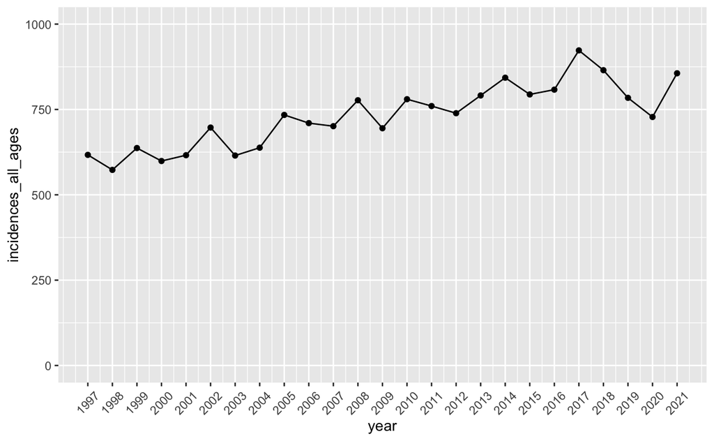

```r
cancer_incidence_borders %>%
  filter(cancer_site == "All cancer types",
         sex == "All") %>%
  ggplot() +
  geom_line(aes(x = year, y = incidences_all_ages)) +
  geom_point(aes(x = year, y = incidences_all_ages)) +
  scale_x_continuous(breaks = c(1997:2021)) +
  theme(axis.text.x = element_text(angle = 45, vjust = 0.5)) +
  ylim(0, 1000)
```

## All Cancer Incidence Trend / Over Time, By Sex

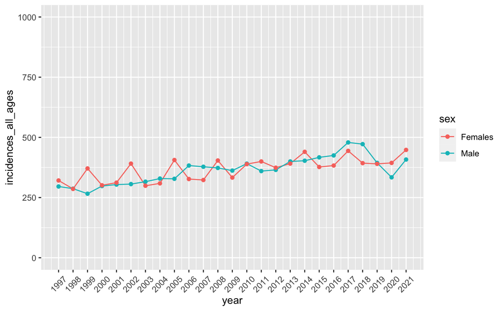

```r
cancer_incidence_borders %>%
  filter(cancer_site == "All cancer types",
         sex != "All") %>%
  ggplot(aes(x = year, y = incidences_all_ages, colour = sex)) +
  geom_line() +
  geom_point() +
  scale_x_continuous(breaks = c(1997:2021)) +
  theme(axis.text.x = element_text(angle = 45, vjust = 0.5)) +
  ylim(0, 1000)
```

## Cancer Types Incidence Trend / Over Time

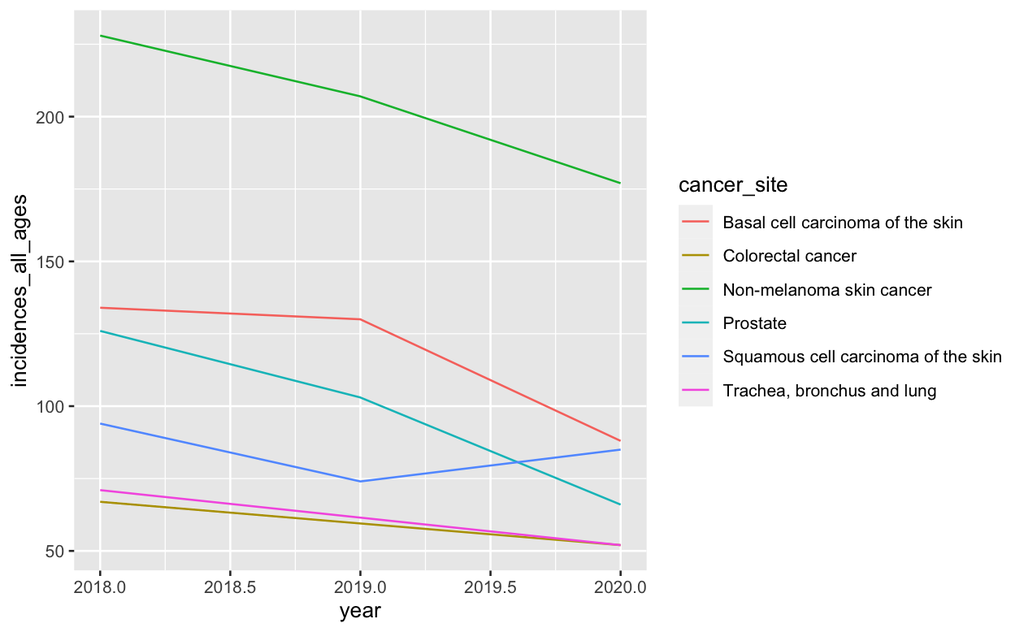

```r
# Note that here we have filtered to only include those with more than 50 incidences.

cancer_incidence_borders %>%
  filter(cancer_site != "All cancer types",
         sex == "Male",
         year %in% c("2018", "2019", "2020"),
         incidences_all_ages > 50) %>%
  ggplot() +
  geom_line(aes(x = year, y = incidences_all_ages,
                 colour = cancer_site))
```

## Cancer Types Incidence Trend / Over Time, By Sex

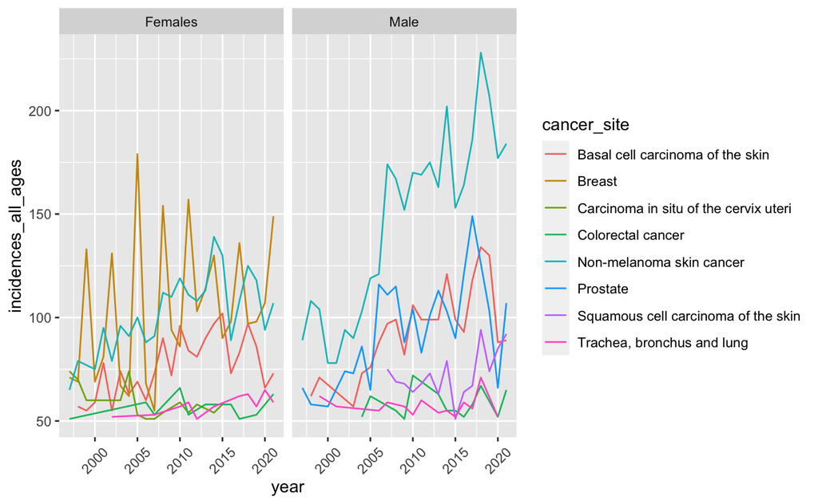

```r
cancer_incidence_borders %>%
  filter(cancer_site != "All cancer types",
         incidences_all_ages > 50,
         sex != "All") %>%
  group_by(year, cancer_site, sex) %>%
  ggplot() +
  geom_line(aes(x = year, y = incidences_all_ages,
                 colour = cancer_site)) +
  facet_wrap(~sex) +
  theme(axis.text.x = element_text(angle = 45, vjust = 0.5))
```

## All Cancer Trend / Over Time, By Age

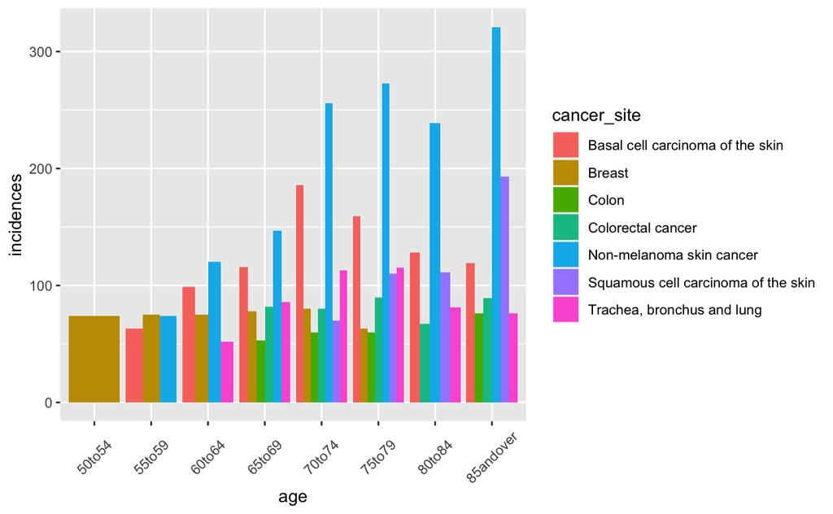

```r
five_year_summary_borders_incidence_long %>%
  filter(sex == "All",
         cancer_site != "All cancer types",
         incidences > 50) %>%
  ggplot() +
  geom_col(aes(x = age, y = incidences,
               fill = cancer_site), position = "dodge") +
  theme(axis.text.x = element_text(angle = 45, vjust = 0.5))
```

## All Cancer Trend / Over Time, By Age & By Sex

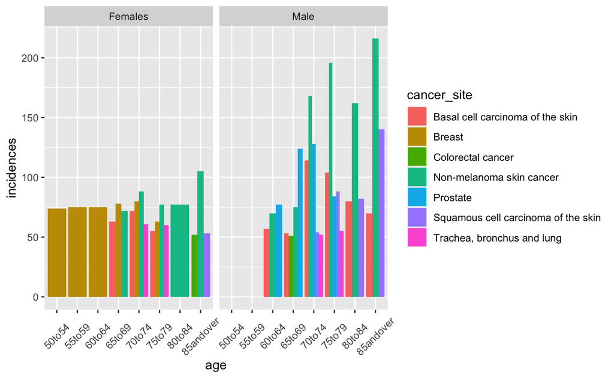

```r
five_year_summary_borders_incidence_long %>%
  filter(sex != "All",
         cancer_site != "All cancer types",
         incidences > 50) %>%
  ggplot() +
  geom_col(aes(x = age, y = incidences,
               fill = cancer_site), position = "dodge") +
  theme(axis.text.x = element_text(angle = 45, vjust = 0.5)) +
  facet_wrap(~sex)
```

# Breast Cancer / Females / 50+

No invites to breast screenings between 30 March 2020 and 3 August 2020 due to the COVID-19 pandemic, resulting in reduction in the overall number of women screened. / https://www.publichealthscotland.scot/media/12843/2022-04-26_breast_screening_report.pdf

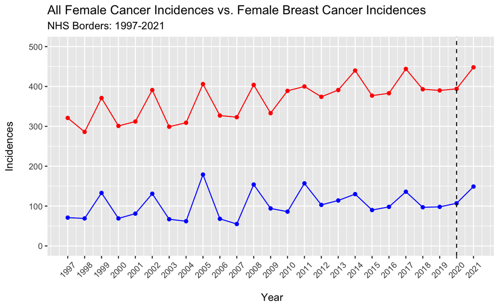

```r
all_cancer_female <- cancer_incidence_borders %>%
  filter(cancer_site == "All cancer types",
         sex == "Females")

breast_cancer_female <- cancer_incidence_borders %>%
  filter(cancer_site == "Breast",
         sex == "Females")

scotland_breast_cancer_female <- cancer_incidence %>%
  filter(cancer_site == "Breast",
         sex == "Females",
         hb %in% c("S08000024", "S08000017"))

ggplot() +
  geom_line(data = all_cancer_female,
            aes(x = year, y = incidences_all_ages),
            colour = "red") +
  geom_point(data = all_cancer_female,
            aes(x = year, y = incidences_all_ages),
            colour = "red") +
  geom_line(data = breast_cancer_female,
            aes(x = year, y = incidences_all_ages),
            colour = "blue") +
  geom_point(data = breast_cancer_female,
            aes(x = year, y = incidences_all_ages),
            colour = "blue") +
  # geom_line(data = scotland_breast_cancer_female,
  #           aes(x = year, y = incidences_all_ages)) +
  # geom_line(data = scotland_breast_cancer_female,
  #           aes(x = year, y = incidences_all_ages, colour = hb),
  #           alpha = 0.5) +
  scale_x_continuous(breaks = c(1997:2021)) +
  theme(axis.text.x = element_text(angle = 45, vjust = 0.5)) +
  ylim(0, 500) +
  labs(
    x = "\n Year",
    y = "Incidences\n",
    title = "All Female Cancer Incidences vs. Female Breast Cancer Incidences",
    subtitle = "NHS Borders: 1997-2021") +
  geom_vline(xintercept = 2020, linetype = "dashed")
```

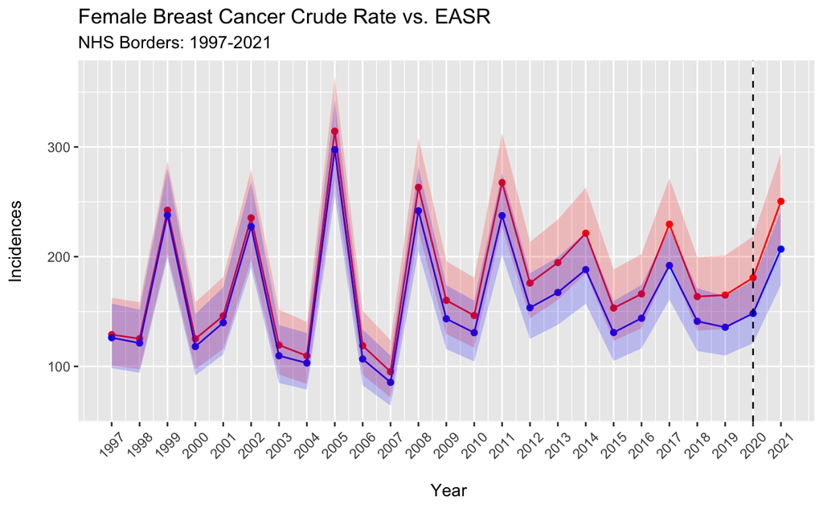

```r
breast_cancer_female %>%
  ggplot() +
  geom_line(aes(x = year, y = crude_rate),
            colour = "red") +
  geom_point(aes(x = year, y = crude_rate),
            colour = "red") +
  geom_line(aes(x = year, y = easr),
            colour = "blue") +
  geom_point(aes(x = year, y = easr),
            colour = "blue") +
  geom_ribbon(aes(x = year,
                  y = crude_rate,
                  ymin = crude_rate_lower95pc_confidence_interval,
                  ymax = crude_rate_upper95pc_confidence_interval),
              alpha = 0.2,
              fill = "red") +
  geom_ribbon(aes(x = year,
                  y = easr,
                  ymin = easr_lower95pc_confidence_interval,
                  ymax = easr_upper95pc_confidence_interval),
              alpha = 0.2,
              fill = "blue") +
  scale_x_continuous(breaks = c(1997:2021)) +
  theme(axis.text.x = element_text(angle = 45, vjust = 0.5)) +
  geom_vline(xintercept = 2020, linetype = "dashed") +
  labs(
    x = "\n Year",
    y = "Incidences\n",
    title = "Female Breast Cancer Crude Rate vs. EASR",
    subtitle = "NHS Borders: 1997-2021")
```

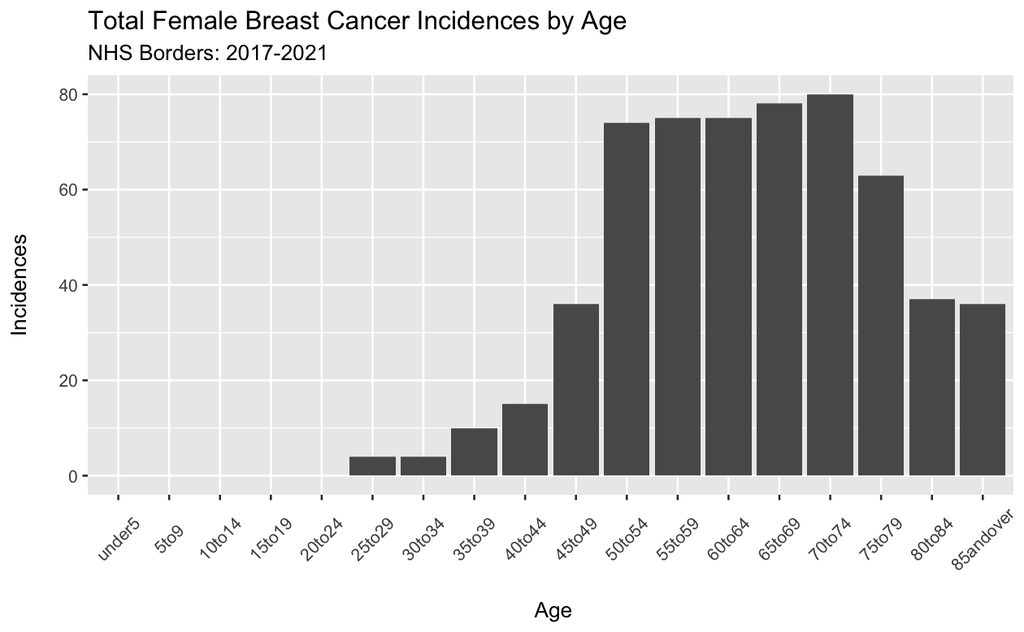

```r
five_year_summary_borders_incidence_long %>%
  filter(cancer_site == "Breast",
         sex == "Females") %>%
  mutate(age = factor(age, levels = c("under5", "5to9",
                                      "10to14", "15to19",
                                      "20to24", "25to29",
                                      "30to34", "35to39",
                                      "40to44", "45to49",
                                      "50to54", "55to59",
                                      "60to64", "65to69",
                                      "70to74", "75to79",
                                      "80to84", "85andover"))) %>%
  ggplot() +
  geom_col(aes(x = age, y = incidences)) +
  theme(axis.text.x = element_text(angle = 45, vjust = 0.5)) +
  labs(
    x = "\n Age",
    y = "Incidences\n",
    title = "Total Female Breast Cancer Incidences by Age",
    subtitle = "NHS Borders: 2017-2021")
```

```r
NA
NA
```

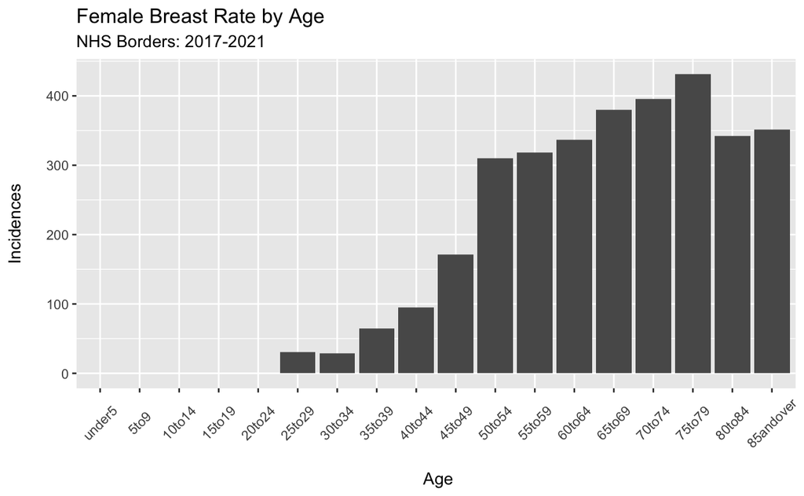

```r
five_year_summary_borders_ratio_long %>%
  filter(cancer_site == "Breast",
         sex == "Females") %>%
  mutate(age = factor(age, levels = c("under5", "5to9",
                                      "10to14", "15to19",
                                      "20to24", "25to29",
                                      "30to34", "35to39",
                                      "40to44", "45to49",
                                      "50to54", "55to59",
                                      "60to64", "65to69",
                                      "70to74", "75to79",
                                      "80to84", "85andover"))) %>%
  ggplot() +
  geom_col(aes(x = age, y = rate)) +
  theme(axis.text.x = element_text(angle = 45, vjust = 0.5)) +
  labs(
    x = "\n Age",
    y = "Incidences\n",
    title = "Female Breast Rate by Age",
    subtitle = "NHS Borders: 2017-2021")
```